# Usando Regressão Linear para Explicar a votação de Deputados

Léo Meira Vital

7 de outubro de 2018

## 1. Um modelo de regressão múltipla com todas as variáveis é plausível para explicar a variação em y (número de votos) em 2006? Mesma pergunta para 2010.

Primeiro, vamos analisar os dados de 2006 para nos familiarizarmos com eles.

```r
d = melt(dados2006)
```

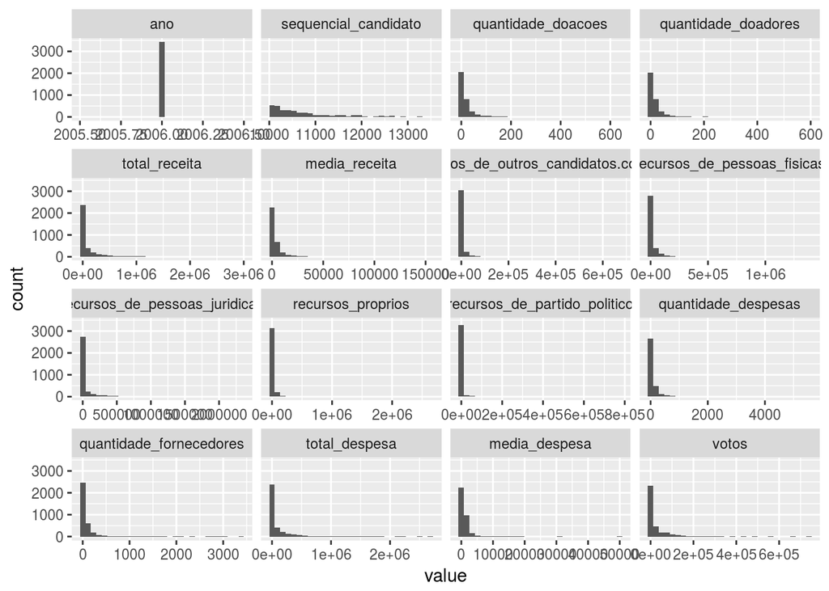

```r
ggplot(d,aes(x = value)) +
    facet_wrap(~variable, scales = "free_x") +
    geom_histogram()
```

Não notamos com essa análise nenhum dado categórico para ser convertido em fator.

Notamos, todavia, que possivelmente há assimetria em diversas das colunas. Escolhemos 13 delas e analisamos a assimetria, usando a função skewness. O resultado de tal análise para os dados de 2006 é o que segue:

```r
cat(skewness(dados2006$quantidade_doacoes),
skewness(dados2006$quantidade_doadores),
skewness(dados2006$total_receita),
skewness(dados2006$media_receita),
skewness(dados2006$recursos_de_outros_candidatos.comites),
skewness(dados2006$recursos_de_pessoas_fisicas),
skewness(dados2006$recursos_de_pessoas_juridicas),
skewness(dados2006$recursos_proprios),
skewness(dados2006$recursos_de_partido_politico),
skewness(dados2006$quantidade_despesas),
skewness(dados2006$quantidade_fornecedores),
skewness(dados2006$total_despesa),
skewness(dados2006$votos))
```

```
## 5.497209 5.374494 4.553111 6.29853 11.14871 9.646415 5.171715 14.73568 13.60591 8.107684 6.98575 4.383576 4.979527
```

Para os dados de 2010, os valores são:

```r
cat(skewness(dados2010$quantidade_doacoes),
skewness(dados2010$quantidade_doadores),
skewness(dados2010$total_receita),
skewness(dados2010$media_receita),
skewness(dados2010$recursos_de_outros_candidatos.comites),
skewness(dados2010$recursos_de_pessoas_fisicas),
skewness(dados2010$recursos_de_pessoas_juridicas),
skewness(dados2010$recursos_proprios),
skewness(dados2010$recursos_de_partido_politico),
skewness(dados2010$quantidade_despesas),
skewness(dados2010$quantidade_fornecedores),
skewness(dados2010$total_despesa),
skewness(dados2010$votos))
```

```
## 32.78821 31.18606 4.044472 11.09752 13.33451 7.30975 4.894368 17.1579 7.694431 7.732556 7.665492 3.90907 7.832938
```

E para os dados de 2006 com os dados de 2010, temos:

```r
cat(skewness(dados2006_2010$quantidade_doacoes),
skewness(dados2006_2010$quantidade_doadores),
skewness(dados2006_2010$total_receita),
skewness(dados2006_2010$media_receita),
skewness(dados2006_2010$recursos_de_outros_candidatos.comites),
skewness(dados2006_2010$recursos_de_pessoas_fisicas),
skewness(dados2006_2010$recursos_de_pessoas_juridicas),
skewness(dados2006_2010$recursos_proprios),
skewness(dados2006_2010$recursos_de_partido_politico),
skewness(dados2006_2010$quantidade_despesas),
skewness(dados2006_2010$quantidade_fornecedores),
skewness(dados2006_2010$total_despesa),
skewness(dados2006_2010$votos))
```

```
## 40.3192 37.85484 4.732082 11.95741 16.89896 8.275992 5.242389 19.22246 10.16089 8.621279 8.498798 4.579522 6.717414
```

Nota-se que todos as colunas selecionadas possuem uma assimetria positiva muito forte (>1). Como muitas das colunas têm valor zero, o que torna o uso da transformação logarítmica não muito adequada, escolhi usar a transformação de raiz cúbica:

```r
dados2006$quantidade_doacoes = dados2006$quantidade_doacoes^(1/3)
dados2006$quantidade_doadores = dados2006$quantidade_doadores^(1/3)
dados2006$total_receita = dados2006$total_receita^(1/3)
dados2006$media_receita = dados2006$media_receita^(1/3)
dados2006$recursos_de_outros_candidatos.comites = dados2006$recursos_de_outros_candidatos.comites^(1/3)
dados2006$recursos_de_pessoas_fisicas = dados2006$recursos_de_pessoas_fisicas^(1/3)
dados2006$recursos_de_pessoas_juridicas = dados2006$recursos_de_pessoas_juridicas^(1/3)
dados2006$recursos_proprios = dados2006$recursos_proprios^(1/3)
dados2006$recursos_de_partido_politico = dados2006$recursos_de_partido_politico^(1/3)
dados2006$quantidade_despesas = dados2006$quantidade_despesas^(1/3)
dados2006$quantidade_fornecedores = dados2006$quantidade_fornecedores^(1/3)
dados2006$total_despesa = dados2006$total_despesa^(1/3)
dados2006$votos = dados2006$votos^(1/3)

dados2010$quantidade_doacoes = dados2010$quantidade_doacoes^(1/3)
dados2010$quantidade_doadores = dados2010$quantidade_doadores^(1/3)
dados2010$total_receita = dados2010$total_receita^(1/3)
dados2010$media_receita = dados2010$media_receita^(1/3)
dados2010$recursos_de_outros_candidatos.comites = dados2010$recursos_de_outros_candidatos.comites^(1/3)
dados2010$recursos_de_pessoas_fisicas = dados2010$recursos_de_pessoas_fisicas^(1/3)
dados2010$recursos_de_pessoas_juridicas = dados2010$recursos_de_pessoas_juridicas^(1/3)
dados2010$recursos_proprios = dados2010$recursos_proprios^(1/3)
dados2010$recursos_de_partido_politico = dados2010$recursos_de_partido_politico^(1/3)
dados2010$quantidade_despesas = dados2010$quantidade_despesas^(1/3)
dados2010$quantidade_fornecedores = dados2010$quantidade_fornecedores^(1/3)
dados2010$total_despesa = dados2010$total_despesa^(1/3)
dados2010$votos = dados2010$votos^(1/3)

dados2006_2010$quantidade_doacoes = dados2006_2010$quantidade_doacoes^(1/3)
dados2006_2010$quantidade_doadores = dados2006_2010$quantidade_doadores^(1/3)
dados2006_2010$total_receita = dados2006_2010$total_receita^(1/3)
dados2006_2010$media_receita = dados2006_2010$media_receita^(1/3)
dados2006_2010$recursos_de_outros_candidatos.comites = dados2006_2010$recursos_de_outros_candidatos.comites^(1/3)
dados2006_2010$recursos_de_pessoas_fisicas = dados2006_2010$recursos_de_pessoas_fisicas^(1/3)
dados2006_2010$recursos_de_pessoas_juridicas = dados2006_2010$recursos_de_pessoas_juridicas^(1/3)
dados2006_2010$recursos_proprios = dados2006_2010$recursos_proprios^(1/3)
dados2006_2010$recursos_de_partido_politico = dados2006_2010$recursos_de_partido_politico^(1/3)
dados2006_2010$quantidade_despesas = dados2006_2010$quantidade_despesas^(1/3)
dados2006_2010$quantidade_fornecedores = dados2006_2010$quantidade_fornecedores^(1/3)
dados2006_2010$total_despesa = dados2006_2010$total_despesa^(1/3)
dados2006_2010$votos = dados2006_2010$votos^(1/3)
```

Façamos agora uma regressão múltipla com os dados mais normalizados para ver se tal modelo é plausível. Note que não levamos em consideração as variáveis categóricas, somente as quantitativas normalizadas acima. Julguei que o sumário dos dados fica muito convoluto quando se inclui as variáveis categóricas, além de ter um impacto no R-squared.

```r
mult2006 = lm(votos ~ quantidade_doacoes + quantidade_doadores + total_receita + media_receita + recursos_de_outros_candidatos.comites + recursos_de_pessoas_fisicas + recursos_de_pessoas_juridicas + recursos_proprios + recursos_de_partido_politico + quantidade_despesas + quantidade_fornecedores + total_despesa, data=dados2006)
summary(mult2006)
```

```
##
## Call:
## lm(formula = votos ~ quantidade_doacoes + quantidade_doadores +
##     total_receita + media_receita + recursos_de_outros_candidatos.comites +
##     recursos_de_pessoas_fisicas + recursos_de_pessoas_juridicas +
##     recursos_proprios + recursos_de_partido_politico + quantidade_despesas +
##     quantidade_fornecedores + total_despesa, data = dados2006)
##
## Residuals:
##     Min      1Q  Median      3Q     Max
## -26.494  -3.738  -0.369   3.186  61.164
##
## Coefficients:
##                                        Estimate Std. Error t value
## (Intercept)                            3.517180   0.650205   5.409
## quantidade_doacoes                     1.094525   1.158455   0.945
## quantidade_doadores                    1.045949   1.168995   0.895
## total_receita                         -0.208569   0.057585  -3.622
## media_receita                          0.250704   0.052134   4.809
## recursos_de_outros_candidatos.comites -0.009931   0.011660  -0.852
## recursos_de_pessoas_fisicas            0.136959   0.013153  10.413
## recursos_de_pessoas_juridicas          0.078854   0.013152   5.996
## recursos_proprios                      0.030122   0.011134   2.705
## recursos_de_partido_politico          -0.011099   0.012382  -0.896
## quantidade_despesas                   -0.103032   0.546469  -0.189
## quantidade_fornecedores               -1.187866   0.588375  -2.019
## total_despesa                          0.521074   0.053457   9.748
##                                       Pr(>|t|)
## (Intercept)                           6.76e-08 ***
## quantidade_doacoes                    0.344820
## quantidade_doadores                   0.370988
## total_receita                         0.000297 ***
## media_receita                         1.58e-06 ***
## recursos_de_outros_candidatos.comites 0.394408
## recursos_de_pessoas_fisicas            < 2e-16 ***
## recursos_de_pessoas_juridicas         2.24e-09 ***
## recursos_proprios                     0.006855 **
## recursos_de_partido_politico          0.370134
## quantidade_despesas                   0.850463
## quantidade_fornecedores               0.043576 *
## total_despesa                          < 2e-16 ***
## ---
## Signif. codes:  0 '***' 0.001 '**' 0.01 '*' 0.05 '.' 0.1 ' ' 1
##
## Residual standard error: 6.413 on 3423 degrees of freedom
## Multiple R-squared:  0.7783, Adjusted R-squared:  0.7775
## F-statistic:  1001 on 12 and 3423 DF,  p-value: < 2.2e-16
```

O R-squared ajustado é de 0.7775, o que é considerável, e indica que a regressão múltipla prediz razoavelmente bem a variação da quantidade de votos.

Agora, vejamos para os dados de 2010:

```r
mult2010 = lm(votos ~ quantidade_doacoes + quantidade_doadores + total_receita + media_receita + recursos_de_outros_candidatos.comites + recursos_de_pessoas_fisicas + recursos_de_pessoas_juridicas + recursos_proprios + recursos_de_partido_politico + quantidade_despesas + quantidade_fornecedores + total_despesa, data=dados2010)
summary(mult2010)
```

```
##
## Call:
## lm(formula = votos ~ quantidade_doacoes + quantidade_doadores +
##     total_receita + media_receita + recursos_de_outros_candidatos.comites +
##     recursos_de_pessoas_fisicas + recursos_de_pessoas_juridicas +
##     recursos_proprios + recursos_de_partido_politico + quantidade_despesas +
##     quantidade_fornecedores + total_despesa, data = dados2010)
##
## Residuals:
##     Min      1Q  Median      3Q     Max
## -37.214  -3.377  -0.570   2.785  79.578
##
## Coefficients:
##                                        Estimate Std. Error t value
## (Intercept)                            4.171855   0.489390   8.525
## quantidade_doacoes                     0.881299   0.728040   1.211
## quantidade_doadores                    0.788581   0.745654   1.058
## total_receita                         -0.202485   0.055611  -3.641
## media_receita                          0.068336   0.037779   1.809
## recursos_de_outros_candidatos.comites  0.035838   0.008830   4.059
## recursos_de_pessoas_fisicas            0.112014   0.010360  10.812
## recursos_de_pessoas_juridicas          0.096953   0.009209  10.528
## recursos_proprios                      0.075037   0.008890   8.441
## recursos_de_partido_politico           0.047281   0.007392   6.396
## quantidade_despesas                    1.129285   0.485601   2.326
## quantidade_fornecedores               -2.369015   0.523461  -4.526
## total_despesa                          0.433134   0.054761   7.909
##                                       Pr(>|t|)
## (Intercept)                            < 2e-16 ***
## quantidade_doacoes                    0.226154
## quantidade_doadores                   0.290315
## total_receita                         0.000275 ***
## media_receita                         0.070556 .
## recursos_de_outros_candidatos.comites 5.03e-05 ***
## recursos_de_pessoas_fisicas            < 2e-16 ***
## recursos_de_pessoas_juridicas          < 2e-16 ***
## recursos_proprios                      < 2e-16 ***
## recursos_de_partido_politico          1.78e-10 ***
## quantidade_despesas                   0.020093 *
## quantidade_fornecedores               6.19e-06 ***
## total_despesa                         3.31e-15 ***
## ---
## Signif. codes:  0 '***' 0.001 '**' 0.01 '*' 0.05 '.' 0.1 ' ' 1
##
## Residual standard error: 6.291 on 4027 degrees of freedom
## Multiple R-squared:  0.8001, Adjusted R-squared:  0.7995
## F-statistic:  1343 on 12 and 4027 DF,  p-value: < 2.2e-16
```

O valor do R-squared ajustado aqui é de 0.7995, ainda maior que o para 2006.

## 2 - Compare as regressões construídas para 2006 e 2010. Quais as diferenças/semelhanças percebidas?

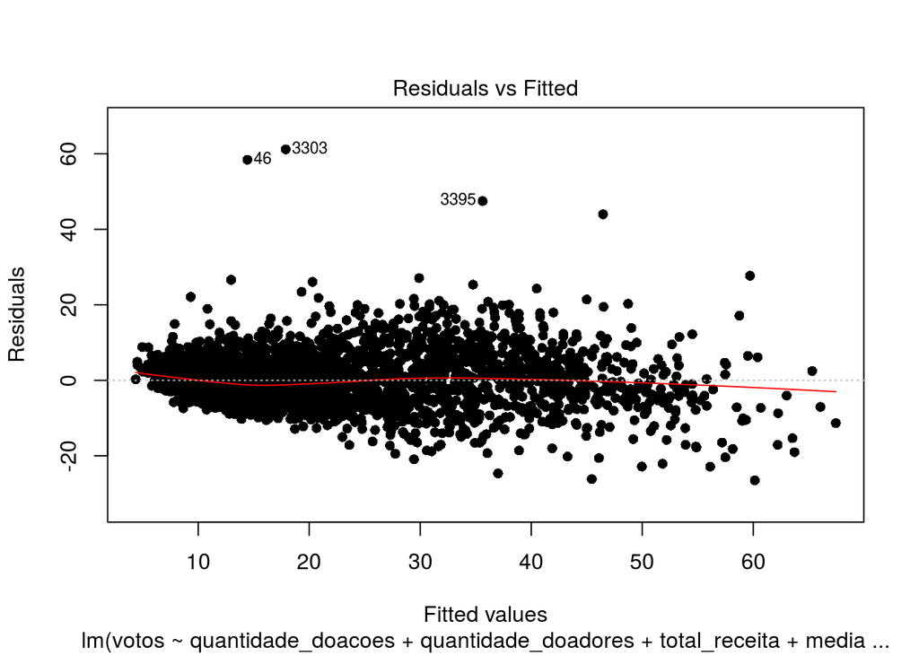

```r
plot(mult2006, pch=16, which=1)
```

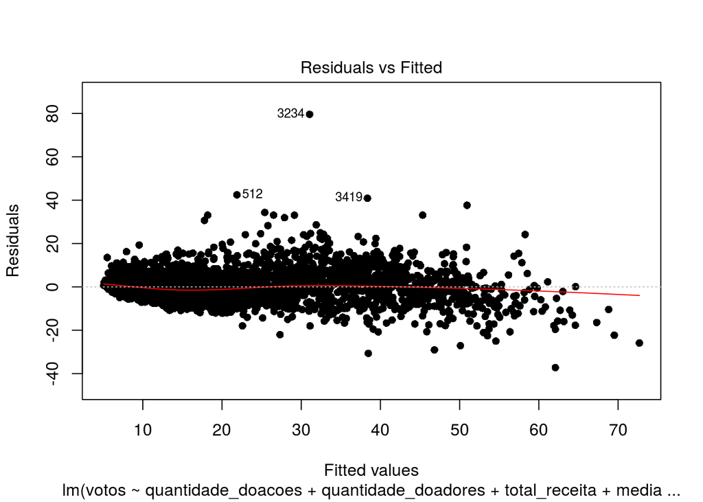

```r
plot(mult2010, pch=16, which=1)
```

Observando-se o plot dos resíduos, nota-se que o modelo de 2010 é mais compacto em torno do eixo de valores esperados, o que talvez explique porque o modelo de 2010 teve um R-squared maior, por explicar melhor os dados que o modelo de 2006.

Com os dados mais normalizados, podemos prosseguir e verificar quais variáveis possuem uma correlação significativa com a variável y (número de votos):

```r
print(round(cor(select(dados2006, -ano, -sequencial_candidato, -nome, -uf, -partido, -cargo, -sexo, -grau, -estado_civil, -ocupacao)),3)[,"votos"] > 0.95)
```

```
##                    quantidade_doacoes
##                                 FALSE
##                   quantidade_doadores
##                                 FALSE
##                         total_receita
##                                 FALSE
##                         media_receita
##                                 FALSE
## recursos_de_outros_candidatos.comites
##                                 FALSE
##           recursos_de_pessoas_fisicas
##                                 FALSE
##         recursos_de_pessoas_juridicas
##                                 FALSE
##                     recursos_proprios
##                                 FALSE
##          recursos_de_partido_politico
##                                 FALSE
##                   quantidade_despesas
##                                 FALSE
##               quantidade_fornecedores
##                                 FALSE
##                         total_despesa
##                                 FALSE
##                         media_despesa
##                                 FALSE
##                                 votos
##                                  TRUE
```

Vemos que não há nenhuma variável com uma correlação forte com os votos. Para os dados de 2010, temos:

```r
print(round(cor(select(dados2010, -ano, -sequencial_candidato, -nome, -uf, -partido, -cargo, -sexo, -grau, -estado_civil, -ocupacao)),3)[,"votos"] > 0.95)
```

```
##                    quantidade_doacoes
##                                 FALSE
##                   quantidade_doadores
##                                 FALSE
##                         total_receita
##                                 FALSE
##                         media_receita
##                                 FALSE
## recursos_de_outros_candidatos.comites
##                                 FALSE
##           recursos_de_pessoas_fisicas
##                                 FALSE
##         recursos_de_pessoas_juridicas
##                                 FALSE
##                     recursos_proprios
##                                 FALSE
##          recursos_de_partido_politico
##                                 FALSE
##                   quantidade_despesas
##                                 FALSE
##               quantidade_fornecedores
##                                 FALSE
##                         total_despesa
##                                 FALSE
##                         media_despesa
##                                 FALSE
##                                 votos
##                                  TRUE
```

Vamos ver os valores de fato das correlações para ver se há algum indicativo de que uma das variáveis tem uma correlação relevante com o número de votos para as eleições de 2006:

```r
print(round(cor(select(dados2006, -ano, -sequencial_candidato, -nome, -uf, -partido, -cargo, -sexo, -grau, -estado_civil, -ocupacao)),3)[,"votos"])
```

```
##                    quantidade_doacoes
##                                 0.713
##                   quantidade_doadores
##                                 0.714
##                         total_receita
##                                 0.864
##                         media_receita
##                                 0.680
## recursos_de_outros_candidatos.comites
##                                 0.311
##           recursos_de_pessoas_fisicas
##                                 0.709
##         recursos_de_pessoas_juridicas
##                                 0.786
##                     recursos_proprios
##                                 0.510
##          recursos_de_partido_politico
##                                 0.277
##                   quantidade_despesas
##                                 0.742
##               quantidade_fornecedores
##                                 0.744
##                         total_despesa
##                                 0.868
##                         media_despesa
##                                 0.348
##                                 votos
##                                 1.000
```

E para as eleições de 2010:

```r
print(round(cor(select(dados2010, -ano, -sequencial_candidato, -nome, -uf, -partido, -cargo, -sexo, -grau, -estado_civil, -ocupacao)),3)[,"votos"])
```

```
##                    quantidade_doacoes
##                                 0.729
##                   quantidade_doadores
##                                 0.726
##                         total_receita
##                                 0.877
##                         media_receita
##                                 0.663
## recursos_de_outros_candidatos.comites
##                                 0.522
##           recursos_de_pessoas_fisicas
##                                 0.739
##         recursos_de_pessoas_juridicas
##                                 0.799
##                     recursos_proprios
##                                 0.535
##          recursos_de_partido_politico
##                                 0.608
##                   quantidade_despesas
##                                 0.774
##               quantidade_fornecedores
##                                 0.776
##                         total_despesa
##                                 0.880
##                         media_despesa
##                                 0.088
##                                 votos
##                                 1.000
```

Tanto total_receita quanto total_despesa são variáveis com alta correlação com o número de votos. Para os dados de 2010, tais variáveis têm uma correlação ligeiramente maior do que as mesmas variáveis para os dados de 2006.

Vamos ver um gráfico de dispersão dessas variáveis para visualizar tal correlação.

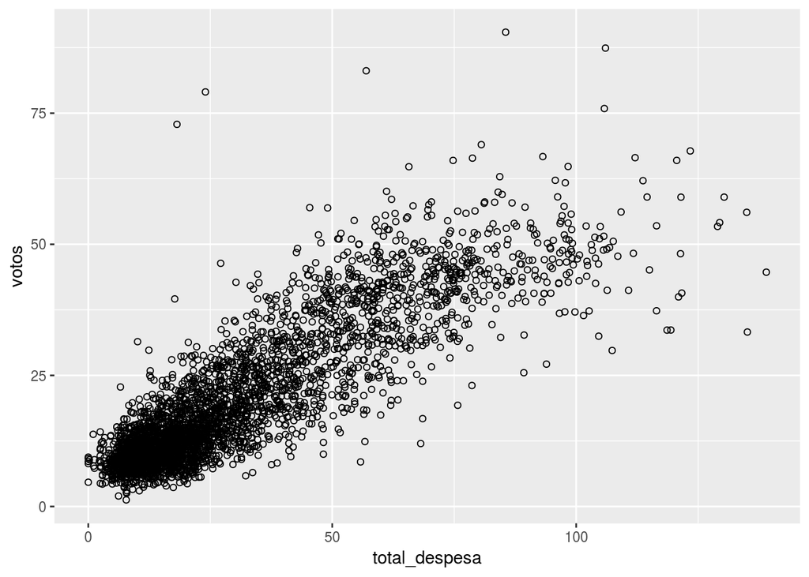

```r
ggplot(dados2006, aes(x=total_despesa, y=votos)) +
    geom_point(shape=1)
```

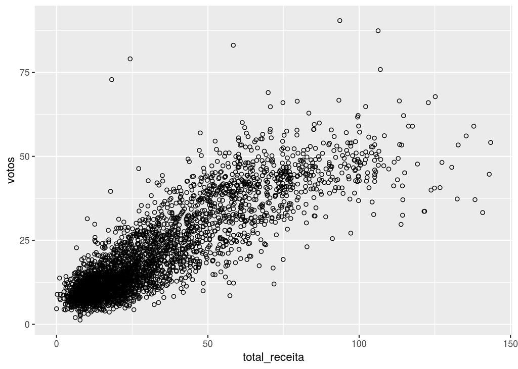

```r
ggplot(dados2006, aes(x=total_receita, y=votos)) +
    geom_point(shape=1)
```

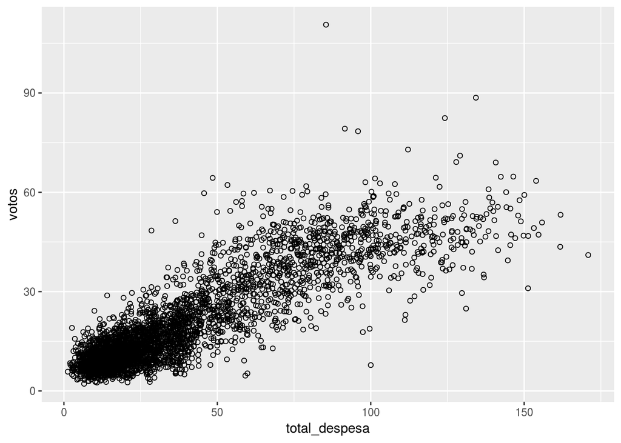

```r
ggplot(dados2010, aes(x=total_despesa, y=votos)) +
    geom_point(shape=1)
```

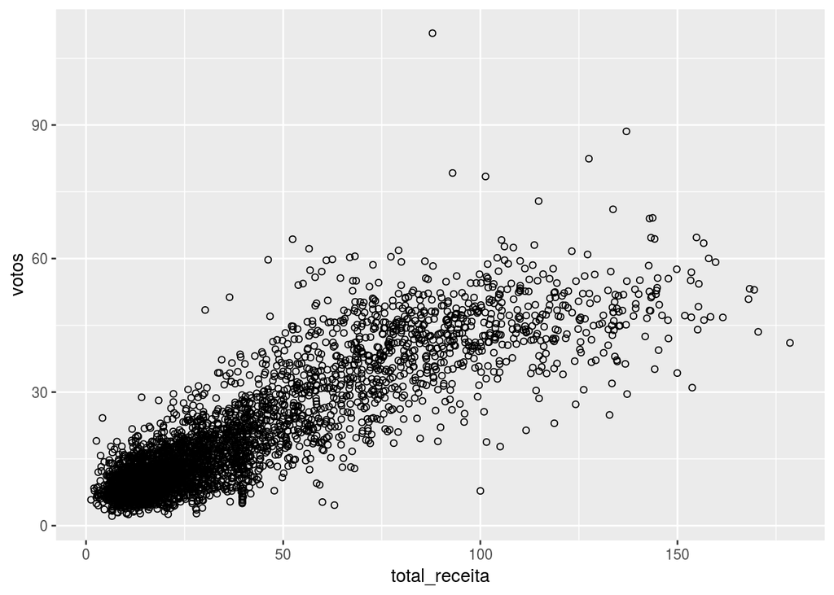

```r
ggplot(dados2010, aes(x=total_receita, y=votos)) +
    geom_point(shape=1)
```

Nota-se uma aparente correlação positiva signitiva ao se ver tais gráficos. Os gráficos de 2010 têm aparentemente uma dispersão um pouco menor, sendo os pontos mais estreitamente unidos do que os gráficos de 2006.

Sobre o R-squared ajustado, tal valor para os dados de 2010 foi de 0.7995, enquanto o do modelo para os dados de 2006 foi 0.7775, o que indica que o modelo de regressão múltipla para os dados de 2010 é mais adequado do que o modelo para 2006.

## 3 - Todas as variáveis são úteis para os modelos de regressão? Há variáveis redudantes? Faça análises para 2006 e 2010 separadamente.

Nem todas as variáveis selecionadas são úteis. Existem variáveis que possuem uma correlação alta entre si, o que as torna um pouco redundantes e pode causar o efeito de multicolinearidade. Vejamos das correlações das variáveis com outras variáveis, quais são consideráveis, primeiro para os dados de 2006:

```r
print(round(cor(select(dados2006, -ano, -sequencial_candidato, -nome, -uf, -partido, -cargo, -sexo, -grau, -estado_civil, -ocupacao)),3) > 0.95)
```

```
##                                       quantidade_doacoes
## quantidade_doacoes                                  TRUE
## quantidade_doadores                                 TRUE
## total_receita                                      FALSE
## media_receita                                      FALSE
## recursos_de_outros_candidatos.comites              FALSE
## recursos_de_pessoas_fisicas                        FALSE
## recursos_de_pessoas_juridicas                      FALSE
## recursos_proprios                                  FALSE
## recursos_de_partido_politico                       FALSE
## quantidade_despesas                                FALSE
## quantidade_fornecedores                            FALSE
## total_despesa                                      FALSE
## media_despesa                                      FALSE
## votos                                              FALSE
##                                       quantidade_doadores total_receita
## quantidade_doacoes                                   TRUE         FALSE
## quantidade_doadores                                  TRUE         FALSE
## total_receita                                       FALSE          TRUE
## media_receita                                       FALSE         FALSE
## recursos_de_outros_candidatos.comites               FALSE         FALSE
## recursos_de_pessoas_fisicas                         FALSE         FALSE
## recursos_de_pessoas_juridicas                       FALSE         FALSE
## recursos_proprios                                   FALSE         FALSE
## recursos_de_partido_politico                        FALSE         FALSE
## quantidade_despesas                                 FALSE         FALSE
## quantidade_fornecedores                             FALSE         FALSE
## total_despesa                                       FALSE          TRUE
## media_despesa                                       FALSE         FALSE
## votos                                               FALSE         FALSE
##                                       media_receita
## quantidade_doacoes                            FALSE
## quantidade_doadores                           FALSE
## total_receita                                 FALSE
## media_receita                                  TRUE
## recursos_de_outros_candidatos.comites         FALSE
## recursos_de_pessoas_fisicas                   FALSE
## recursos_de_pessoas_juridicas                 FALSE
## recursos_proprios                             FALSE
## recursos_de_partido_politico                  FALSE
```

[output cut: 110 more lines]

```
##                                       total_despesa media_despesa votos
## quantidade_doacoes                            FALSE         FALSE FALSE
## quantidade_doadores                           FALSE         FALSE FALSE
## total_receita                                  TRUE         FALSE FALSE
## media_receita                                 FALSE         FALSE FALSE
## recursos_de_outros_candidatos.comites         FALSE         FALSE FALSE
## recursos_de_pessoas_fisicas                   FALSE         FALSE FALSE
## recursos_de_pessoas_juridicas                 FALSE         FALSE FALSE
## recursos_proprios                             FALSE         FALSE FALSE
## recursos_de_partido_politico                  FALSE         FALSE FALSE
## quantidade_despesas                           FALSE         FALSE FALSE
## quantidade_fornecedores                       FALSE         FALSE FALSE
## total_despesa                                  TRUE         FALSE FALSE
## media_despesa                                 FALSE          TRUE FALSE
## votos                                         FALSE         FALSE  TRUE
```

quantidade_doadores tem uma correlação bastante alta com quantidade_doacoes, o que é previsível.

total_receita tem uma correlação bastante alta com total_despesa, o que também é previsível, pois quanto mais for arrecadado mais se pode gastar.

Por fim, quantidade_fornecedores tem uma correlação bastante alta com quantidade_despesas.

Tais pares de variáveis podem ser considerados redundantes quando estão juntos num modelo, e portanto pode ser preferível selecionar somente um por par.

Além disso, vejamos o p-valor para cada variável no modelo de 2006:

```r
summary(mult2006)
```

```
##
## Call:
## lm(formula = votos ~ quantidade_doacoes + quantidade_doadores +
##     total_receita + media_receita + recursos_de_outros_candidatos.comites +
##     recursos_de_pessoas_fisicas + recursos_de_pessoas_juridicas +
##     recursos_proprios + recursos_de_partido_politico + quantidade_despesas +
##     quantidade_fornecedores + total_despesa, data = dados2006)
##
## Residuals:
##     Min      1Q  Median      3Q     Max
## -26.494  -3.738  -0.369   3.186  61.164
##
## Coefficients:
##                                        Estimate Std. Error t value
## (Intercept)                            3.517180   0.650205   5.409
## quantidade_doacoes                     1.094525   1.158455   0.945
## quantidade_doadores                    1.045949   1.168995   0.895
## total_receita                         -0.208569   0.057585  -3.622
## media_receita                          0.250704   0.052134   4.809
## recursos_de_outros_candidatos.comites -0.009931   0.011660  -0.852
## recursos_de_pessoas_fisicas            0.136959   0.013153  10.413
## recursos_de_pessoas_juridicas          0.078854   0.013152   5.996
## recursos_proprios                      0.030122   0.011134   2.705
## recursos_de_partido_politico          -0.011099   0.012382  -0.896
## quantidade_despesas                   -0.103032   0.546469  -0.189
## quantidade_fornecedores               -1.187866   0.588375  -2.019
## total_despesa                          0.521074   0.053457   9.748
##                                       Pr(>|t|)
## (Intercept)                           6.76e-08 ***
## quantidade_doacoes                    0.344820
## quantidade_doadores                   0.370988
## total_receita                         0.000297 ***
## media_receita                         1.58e-06 ***
## recursos_de_outros_candidatos.comites 0.394408
## recursos_de_pessoas_fisicas            < 2e-16 ***
## recursos_de_pessoas_juridicas         2.24e-09 ***
## recursos_proprios                     0.006855 **
## recursos_de_partido_politico          0.370134
## quantidade_despesas                   0.850463
## quantidade_fornecedores               0.043576 *
## total_despesa                          < 2e-16 ***
## ---
## Signif. codes:  0 '***' 0.001 '**' 0.01 '*' 0.05 '.' 0.1 ' ' 1
##
## Residual standard error: 6.413 on 3423 degrees of freedom
## Multiple R-squared:  0.7783, Adjusted R-squared:  0.7775
## F-statistic:  1001 on 12 and 3423 DF,  p-value: < 2.2e-16
```

Para os dados de 2010, temos:

```r
print(round(cor(select(dados2010, -ano, -sequencial_candidato, -nome, -uf, -partido, -cargo, -sexo, -grau, -estado_civil, -ocupacao)),3) > 0.95)
```

```
##                                       quantidade_doacoes
## quantidade_doacoes                                  TRUE
## quantidade_doadores                                 TRUE
## total_receita                                      FALSE
## media_receita                                      FALSE
## recursos_de_outros_candidatos.comites              FALSE
## recursos_de_pessoas_fisicas                        FALSE
## recursos_de_pessoas_juridicas                      FALSE
## recursos_proprios                                  FALSE
## recursos_de_partido_politico                       FALSE
## quantidade_despesas                                FALSE
## quantidade_fornecedores                            FALSE
## total_despesa                                      FALSE
## media_despesa                                      FALSE
## votos                                              FALSE
##                                       quantidade_doadores total_receita
## quantidade_doacoes                                   TRUE         FALSE
## quantidade_doadores                                  TRUE         FALSE
## total_receita                                       FALSE          TRUE
## media_receita                                       FALSE         FALSE
## recursos_de_outros_candidatos.comites               FALSE         FALSE
## recursos_de_pessoas_fisicas                         FALSE         FALSE
## recursos_de_pessoas_juridicas                       FALSE         FALSE
## recursos_proprios                                   FALSE         FALSE
## recursos_de_partido_politico                        FALSE         FALSE
## quantidade_despesas                                 FALSE         FALSE
## quantidade_fornecedores                             FALSE         FALSE
## total_despesa                                       FALSE          TRUE
## media_despesa                                       FALSE         FALSE
## votos                                               FALSE         FALSE
##                                       media_receita
## quantidade_doacoes                            FALSE
## quantidade_doadores                           FALSE
## total_receita                                 FALSE
## media_receita                                  TRUE
## recursos_de_outros_candidatos.comites         FALSE
## recursos_de_pessoas_fisicas                   FALSE
## recursos_de_pessoas_juridicas                 FALSE
## recursos_proprios                             FALSE
## recursos_de_partido_politico                  FALSE
```

[output cut: 110 more lines]

```
##                                       total_despesa media_despesa votos
## quantidade_doacoes                            FALSE         FALSE FALSE
## quantidade_doadores                           FALSE         FALSE FALSE
## total_receita                                  TRUE         FALSE FALSE
## media_receita                                 FALSE         FALSE FALSE
## recursos_de_outros_candidatos.comites         FALSE         FALSE FALSE
## recursos_de_pessoas_fisicas                   FALSE         FALSE FALSE
## recursos_de_pessoas_juridicas                 FALSE         FALSE FALSE
## recursos_proprios                             FALSE         FALSE FALSE
## recursos_de_partido_politico                  FALSE         FALSE FALSE
## quantidade_despesas                           FALSE         FALSE FALSE
## quantidade_fornecedores                       FALSE         FALSE FALSE
## total_despesa                                  TRUE         FALSE FALSE
## media_despesa                                 FALSE          TRUE FALSE
## votos                                         FALSE         FALSE  TRUE
```

Os mesmos pares de variáveis redundantes aparecem para os dados de 2010!

Sobre o p-valor das variáveis do modelo de 2010, temos:

```r
summary(mult2010)
```

```
##
## Call:
## lm(formula = votos ~ quantidade_doacoes + quantidade_doadores +
##     total_receita + media_receita + recursos_de_outros_candidatos.comites +
##     recursos_de_pessoas_fisicas + recursos_de_pessoas_juridicas +
##     recursos_proprios + recursos_de_partido_politico + quantidade_despesas +
##     quantidade_fornecedores + total_despesa, data = dados2010)
##
## Residuals:
##     Min      1Q  Median      3Q     Max
## -37.214  -3.377  -0.570   2.785  79.578
##
## Coefficients:
##                                        Estimate Std. Error t value
## (Intercept)                            4.171855   0.489390   8.525
## quantidade_doacoes                     0.881299   0.728040   1.211
## quantidade_doadores                    0.788581   0.745654   1.058
## total_receita                         -0.202485   0.055611  -3.641
## media_receita                          0.068336   0.037779   1.809
## recursos_de_outros_candidatos.comites  0.035838   0.008830   4.059
## recursos_de_pessoas_fisicas            0.112014   0.010360  10.812
## recursos_de_pessoas_juridicas          0.096953   0.009209  10.528
## recursos_proprios                      0.075037   0.008890   8.441
## recursos_de_partido_politico           0.047281   0.007392   6.396
## quantidade_despesas                    1.129285   0.485601   2.326
## quantidade_fornecedores               -2.369015   0.523461  -4.526
## total_despesa                          0.433134   0.054761   7.909
##                                       Pr(>|t|)
## (Intercept)                            < 2e-16 ***
## quantidade_doacoes                    0.226154
## quantidade_doadores                   0.290315
## total_receita                         0.000275 ***
## media_receita                         0.070556 .
## recursos_de_outros_candidatos.comites 5.03e-05 ***
## recursos_de_pessoas_fisicas            < 2e-16 ***
## recursos_de_pessoas_juridicas          < 2e-16 ***
## recursos_proprios                      < 2e-16 ***
## recursos_de_partido_politico          1.78e-10 ***
## quantidade_despesas                   0.020093 *
## quantidade_fornecedores               6.19e-06 ***
## total_despesa                         3.31e-15 ***
## ---
## Signif. codes:  0 '***' 0.001 '**' 0.01 '*' 0.05 '.' 0.1 ' ' 1
##
## Residual standard error: 6.291 on 4027 degrees of freedom
## Multiple R-squared:  0.8001, Adjusted R-squared:  0.7995
## F-statistic:  1343 on 12 and 4027 DF,  p-value: < 2.2e-16
```

Além disso, vale salientar que desconsiderei variáveis categóricas por achar mais adequado fazer tal regressão múltipla focada em variáveis quantitativas. Além de haver variáveis categóricas claramente inúteis, como cargo e ano, que só possuem um valor e portanto não explicam nada, temos outras variáveis que só tornariam o modelo excessivamente complexo por adicionar muita variabilidade, como ocupacao.

Também nota-se variáveis que são únicas para cada linha, como sequencial_candidato e nome, que também não explicariam nada e portanto foram desconsideradas.

## 4 - No caso de haver variáveis pouco explicativas e/ou redudantes, construa um novo modelo sem essas variáveis e o compare ao modelo com todas as variáveis (e.g. em termos de R2 e RSE). Faça isso para 2006 e 2010 separadamente.

```r
mult2006_modificado = lm(votos ~ total_receita + media_receita + recursos_de_pessoas_fisicas + recursos_de_pessoas_juridicas + recursos_proprios, data=dados2006)
summary(mult2006_modificado)
```

```
##
## Call:
## lm(formula = votos ~ total_receita + media_receita + recursos_de_pessoas_fisicas +
##     recursos_de_pessoas_juridicas + recursos_proprios, data = dados2006)
##
## Residuals:
##     Min      1Q  Median      3Q     Max
## -32.920  -3.670  -0.623   3.047  62.122
##
## Coefficients:
##                               Estimate Std. Error t value Pr(>|t|)
## (Intercept)                    6.06919    0.28802  21.072   <2e-16 ***
## total_receita                  0.31557    0.01905  16.565   <2e-16 ***
## media_receita                  0.05368    0.03308   1.623    0.105
## recursos_de_pessoas_fisicas    0.16389    0.01199  13.673   <2e-16 ***
## recursos_de_pessoas_juridicas  0.06648    0.01182   5.625    2e-08 ***
## recursos_proprios              0.01146    0.01026   1.117    0.264
## ---
## Signif. codes:  0 '***' 0.001 '**' 0.01 '*' 0.05 '.' 0.1 ' ' 1
##
## Residual standard error: 6.642 on 3430 degrees of freedom
## Multiple R-squared:  0.7616, Adjusted R-squared:  0.7613
## F-statistic:  2192 on 5 and 3430 DF,  p-value: < 2.2e-16
```

Tal modelo tem um R-squared ajustado de 0.7613, o que é bastante semelhante ao modelo com todas as variáveis retiradas, e é bem mais enxuto.

Algo curioso ao se comparar este modelo com o anterior de 2006 é que no modelo anterior, total_receita tem um impacto estimado de -0.208569 sobre a quantidade de votos, enquanto aqui ele tem um impacto estimado de 0.31557. Ou seja, enquanto que o modelo anterior dá a entender que quanto mais receita, menos votos (o que é contra-intuitivo), o modelo modificado faz mais sentido, dizendo que quanto maior a receita maior a quantidade de votos no candidato.

Fazendo o mesmo para os dados de 2010, removeremos, além dos pares de variáveis redundantes (quantidade_doadores, total_despesa e quantidade_despesas), os com p-valor alto, quais sejam: quantidade_doacoes e media_receita. Ficamos então com:

```r
mult2010_modificado = lm(votos ~ total_receita + recursos_de_outros_candidatos.comites + recursos_de_pessoas_fisicas + recursos_de_pessoas_juridicas + recursos_proprios + recursos_de_partido_politico + quantidade_fornecedores, data=dados2010)
summary(mult2010_modificado)
```

```
##
## Call:
## lm(formula = votos ~ total_receita + recursos_de_outros_candidatos.comites +
##     recursos_de_pessoas_fisicas + recursos_de_pessoas_juridicas +
##     recursos_proprios + recursos_de_partido_politico + quantidade_fornecedores,
##     data = dados2010)
##
## Residuals:
##     Min      1Q  Median      3Q     Max
## -36.953  -3.378  -0.674   2.760  78.704
##
## Coefficients:
##                                        Estimate Std. Error t value
## (Intercept)                            6.620852   0.205944  32.149
## total_receita                          0.228212   0.014006  16.294
## recursos_de_outros_candidatos.comites  0.048594   0.008657   5.614
## recursos_de_pessoas_fisicas            0.159828   0.008931  17.896
## recursos_de_pessoas_juridicas          0.094901   0.008804  10.780
## recursos_proprios                      0.078304   0.008946   8.753
## recursos_de_partido_politico           0.051051   0.007353   6.943
## quantidade_fornecedores               -0.827976   0.097923  -8.455
##                                       Pr(>|t|)
## (Intercept)                            < 2e-16 ***
## total_receita                          < 2e-16 ***
## recursos_de_outros_candidatos.comites 2.12e-08 ***
## recursos_de_pessoas_fisicas            < 2e-16 ***
## recursos_de_pessoas_juridicas          < 2e-16 ***
## recursos_proprios                      < 2e-16 ***
## recursos_de_partido_politico          4.47e-12 ***
## quantidade_fornecedores                < 2e-16 ***
## ---
## Signif. codes:  0 '***' 0.001 '**' 0.01 '*' 0.05 '.' 0.1 ' ' 1
##
## Residual standard error: 6.425 on 4032 degrees of freedom
## Multiple R-squared:  0.7911, Adjusted R-squared:  0.7908
## F-statistic:  2182 on 7 and 4032 DF,  p-value: < 2.2e-16
```

Temos para os dados de 2010 também a curiosa inversão do impacto negativo de total_receita para um impacto positivo.

## 5 - Construa agora uma regressão considerando os anos 2006 e 2010 em conjunto. Que diferenças/semelhanças você percebe em relação aos modelos individuais por ano?

Usaremos as mesmas variáveis inicialmente selecionadas para os modelos de 2006 e de 2010:

```r
mult2006_2010 = lm(votos ~ quantidade_doacoes + quantidade_doadores + total_receita + media_receita + recursos_de_outros_candidatos.comites + recursos_de_pessoas_fisicas + recursos_de_pessoas_juridicas + recursos_proprios + recursos_de_partido_politico + quantidade_despesas + quantidade_fornecedores + total_despesa, data=dados2006_2010)
summary(mult2006_2010)
```

```
##
## Call:
## lm(formula = votos ~ quantidade_doacoes + quantidade_doadores +
##     total_receita + media_receita + recursos_de_outros_candidatos.comites +
##     recursos_de_pessoas_fisicas + recursos_de_pessoas_juridicas +
##     recursos_proprios + recursos_de_partido_politico + quantidade_despesas +
##     quantidade_fornecedores + total_despesa, data = dados2006_2010)
##
## Residuals:
##     Min      1Q  Median      3Q     Max
## -35.723  -3.678  -0.699   3.096  81.299
##
## Coefficients:
##                                        Estimate Std. Error t value
## (Intercept)                            3.299975   0.402659   8.195
## quantidade_doacoes                     0.862346   0.640277   1.347
## quantidade_doadores                    1.414120   0.647399   2.184
## total_receita                         -0.147946   0.041087  -3.601
## media_receita                          0.205333   0.031627   6.492
## recursos_de_outros_candidatos.comites -0.025012   0.007129  -3.509
## recursos_de_pessoas_fisicas            0.110460   0.008439  13.090
## recursos_de_pessoas_juridicas          0.106784   0.007835  13.629
## recursos_proprios                      0.045414   0.007188   6.318
## recursos_de_partido_politico          -0.018325   0.006096  -3.006
## quantidade_despesas                    0.610256   0.368840   1.655
## quantidade_fornecedores               -1.654322   0.396957  -4.168
## total_despesa                          0.386745   0.039561   9.776
##                                       Pr(>|t|)
## (Intercept)                           2.91e-16 ***
## quantidade_doacoes                    0.178075
## quantidade_doadores                   0.028970 *
## total_receita                         0.000319 ***
## media_receita                         8.99e-11 ***
## recursos_de_outros_candidatos.comites 0.000453 ***
## recursos_de_pessoas_fisicas            < 2e-16 ***
## recursos_de_pessoas_juridicas          < 2e-16 ***
## recursos_proprios                     2.80e-10 ***
## recursos_de_partido_politico          0.002655 **
## quantidade_despesas                   0.098062 .
## quantidade_fornecedores               3.11e-05 ***
## total_despesa                          < 2e-16 ***
## ---
## Signif. codes:  0 '***' 0.001 '**' 0.01 '*' 0.05 '.' 0.1 ' ' 1
##
## Residual standard error: 6.646 on 7463 degrees of freedom
## Multiple R-squared:  0.7704, Adjusted R-squared:   0.77
## F-statistic:  2087 on 12 and 7463 DF,  p-value: < 2.2e-16
```

```r
print(round(cor(select(dados2006_2010, -ano, -sequencial_candidato, -nome, -uf, -partido, -cargo, -sexo, -grau, -estado_civil, -ocupacao)),3) > 0.95)
```

```
##                                       quantidade_doacoes
## quantidade_doacoes                                  TRUE
## quantidade_doadores                                 TRUE
## total_receita                                      FALSE
## media_receita                                      FALSE
## recursos_de_outros_candidatos.comites              FALSE
## recursos_de_pessoas_fisicas                        FALSE
## recursos_de_pessoas_juridicas                      FALSE
## recursos_proprios                                  FALSE
## recursos_de_partido_politico                       FALSE
## quantidade_despesas                                FALSE
## quantidade_fornecedores                            FALSE
## total_despesa                                      FALSE
## media_despesa                                      FALSE
## votos                                              FALSE
##                                       quantidade_doadores total_receita
## quantidade_doacoes                                   TRUE         FALSE
## quantidade_doadores                                  TRUE         FALSE
## total_receita                                       FALSE          TRUE
## media_receita                                       FALSE         FALSE
## recursos_de_outros_candidatos.comites               FALSE         FALSE
## recursos_de_pessoas_fisicas                         FALSE         FALSE
## recursos_de_pessoas_juridicas                       FALSE         FALSE
## recursos_proprios                                   FALSE         FALSE
## recursos_de_partido_politico                        FALSE         FALSE
## quantidade_despesas                                 FALSE         FALSE
## quantidade_fornecedores                             FALSE         FALSE
## total_despesa                                       FALSE          TRUE
## media_despesa                                       FALSE         FALSE
## votos                                               FALSE         FALSE
##                                       media_receita
## quantidade_doacoes                            FALSE
## quantidade_doadores                           FALSE
## total_receita                                 FALSE
## media_receita                                  TRUE
## recursos_de_outros_candidatos.comites         FALSE
## recursos_de_pessoas_fisicas                   FALSE
## recursos_de_pessoas_juridicas                 FALSE
## recursos_proprios                             FALSE
## recursos_de_partido_politico                  FALSE
```

[output cut: 110 more lines]

```
##                                       total_despesa media_despesa votos
## quantidade_doacoes                            FALSE         FALSE FALSE
## quantidade_doadores                           FALSE         FALSE FALSE
## total_receita                                  TRUE         FALSE FALSE
## media_receita                                 FALSE         FALSE FALSE
## recursos_de_outros_candidatos.comites         FALSE         FALSE FALSE
## recursos_de_pessoas_fisicas                   FALSE         FALSE FALSE
## recursos_de_pessoas_juridicas                 FALSE         FALSE FALSE
## recursos_proprios                             FALSE         FALSE FALSE
## recursos_de_partido_politico                  FALSE         FALSE FALSE
## quantidade_despesas                           FALSE         FALSE FALSE
## quantidade_fornecedores                       FALSE         FALSE FALSE
## total_despesa                                  TRUE         FALSE FALSE
## media_despesa                                 FALSE          TRUE FALSE
## votos                                         FALSE         FALSE  TRUE
```

Vendo isso, temos os mesmos pares de relações com correlação alta que tínhamos para os dados de 2006 e de 2010.

Nota-se que total_receita tem impacto negativo no modelo atualmente. Removamos as variáveis redundantes e com p-valor baixo para ver se isso muda:

```r
mult2006_2010_modificado = lm(votos ~ total_receita + media_receita + recursos_de_outros_candidatos.comites + recursos_de_pessoas_fisicas + recursos_de_pessoas_juridicas + recursos_proprios + recursos_de_partido_politico + quantidade_fornecedores, data=dados2006_2010)
summary(mult2006_2010_modificado)
```

```
##
## Call:
## lm(formula = votos ~ total_receita + media_receita + recursos_de_outros_candidatos.comites +
##     recursos_de_pessoas_fisicas + recursos_de_pessoas_juridicas +
##     recursos_proprios + recursos_de_partido_politico + quantidade_fornecedores,
##     data = dados2006_2010)
##
## Residuals:
##     Min      1Q  Median      3Q     Max
## -36.391  -3.658  -0.839   3.009  79.897
##
## Coefficients:
##                                        Estimate Std. Error t value
## (Intercept)                            7.699957   0.225090  34.208
## total_receita                          0.336533   0.016221  20.747
## media_receita                         -0.068934   0.022594  -3.051
## recursos_de_outros_candidatos.comites -0.024892   0.007278  -3.420
## recursos_de_pessoas_fisicas            0.145010   0.008143  17.808
## recursos_de_pessoas_juridicas          0.090642   0.007773  11.662
## recursos_proprios                      0.041986   0.007312   5.742
## recursos_de_partido_politico          -0.022118   0.006171  -3.584
## quantidade_fornecedores               -0.812973   0.085964  -9.457
##                                       Pr(>|t|)
## (Intercept)                            < 2e-16 ***
## total_receita                          < 2e-16 ***
## media_receita                         0.002289 **
## recursos_de_outros_candidatos.comites 0.000629 ***
## recursos_de_pessoas_fisicas            < 2e-16 ***
## recursos_de_pessoas_juridicas          < 2e-16 ***
## recursos_proprios                     9.71e-09 ***
## recursos_de_partido_politico          0.000340 ***
## quantidade_fornecedores                < 2e-16 ***
## ---
## Signif. codes:  0 '***' 0.001 '**' 0.01 '*' 0.05 '.' 0.1 ' ' 1
##
## Residual standard error: 6.787 on 7467 degrees of freedom
## Multiple R-squared:  0.7604, Adjusted R-squared:  0.7601
## F-statistic:  2962 on 8 and 7467 DF,  p-value: < 2.2e-16
```

Agora temos total_receita com um valor positivo, como também aconteceu ao se ajustar os modelos anteriores.

Por fim, vejamos o plot dos resíduos:

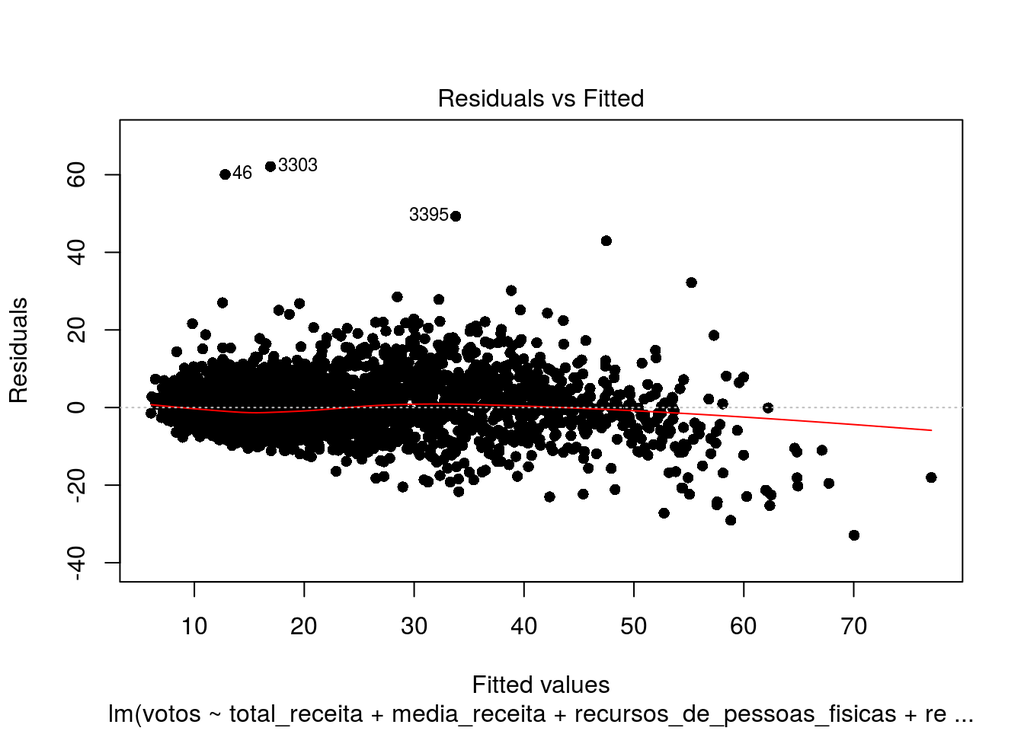

```r
plot(mult2006_modificado, pch=16, which=1)
```

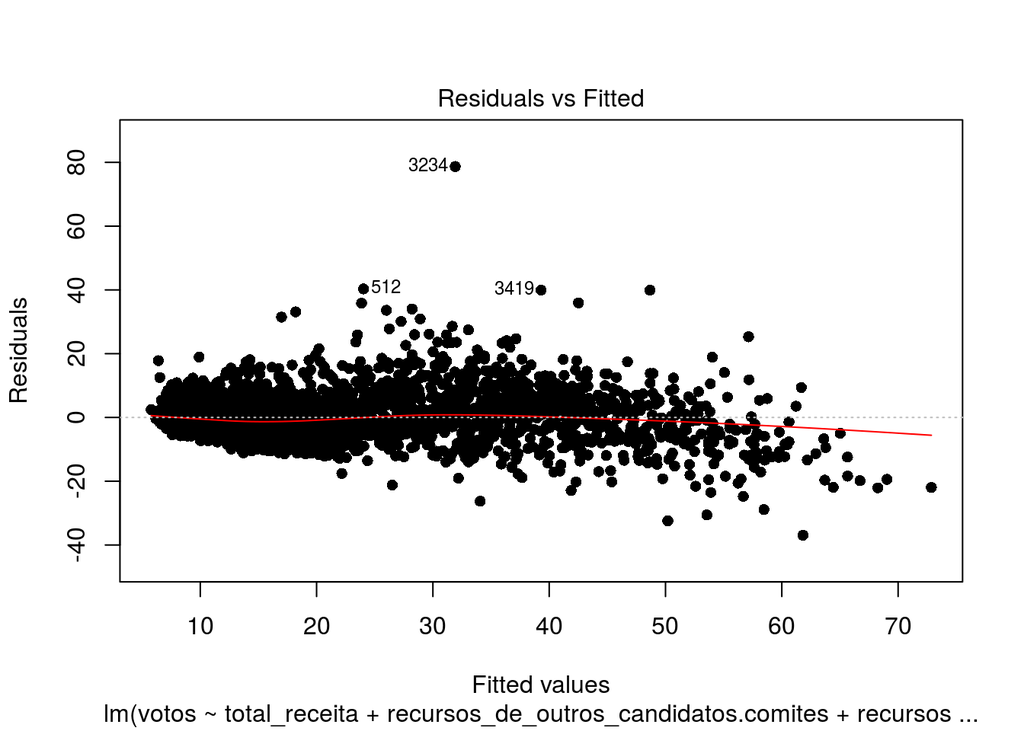

```r
plot(mult2010_modificado, pch=16, which=1)
```

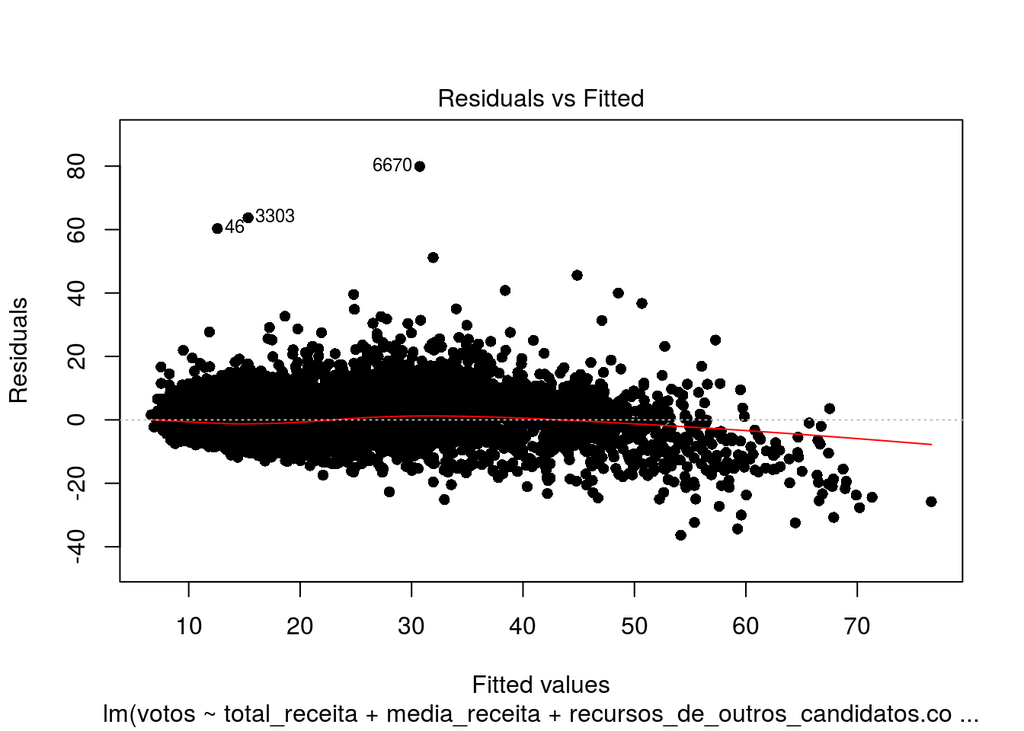

```r
plot(mult2006_2010_modificado, pch=16, which=1)
```

A parte mais à direita do plot de 2006 e 2010, mais esparsa, parece mais com a mesma parte do plot de 2010; enquanto que a parte mais à esquerda, mais estreita, parece mais com a mesma parte do plot de 2006.